# Linear Regression on Concrete Strength Dataset

Yeh, I. (1998). Concrete Compressive Strength [Dataset]. UCI Machine Learning Repository. https://doi.org/10.24432/C5PK67.

# Process the Dataset

```r
#store dataset
dataset = read.csv("Concrete_Data.csv")


#Removes duplicate rows
dataset = unique(dataset)

#rename columns of dataset for simplicity
colnames(dataset) = c("Cement","Blast Furnace Slag","Fly Ash","Water","Superplasticizer","Coarse Aggregate","Fine Aggregate","Age","CCS")

#CCS -> Concrete compressive strength

#store the dimensions of dataset
n = nrow(dataset)                         #number of instances
p = ncol(dataset) - 1                     #number of predictors
```

# Exploratory data analysis

## Summary Statistics

Number of instances: 1005  
Number of Attributes: 9  
Attribute breakdown: 8 quantitative input variables, and 1 quantitative output variable

```r
spread = NULL
for(i in 1:p)
  spread = cbind(spread,c(sd(dataset[,i]),range(dataset[,i])))

colnames(spread) = colnames(dataset[1:8])
rownames(spread) = c("Std Deviation","Min","Max")

summary(dataset)
```

```
##      Cement      Blast Furnace Slag    Fly Ash           Water
##  Min.   :102.0   Min.   :  0.00     Min.   :  0.00   Min.   :121.8
##  1st Qu.:190.7   1st Qu.:  0.00     1st Qu.:  0.00   1st Qu.:166.6
##  Median :265.0   Median : 20.00     Median :  0.00   Median :185.7
##  Mean   :278.6   Mean   : 72.04     Mean   : 55.54   Mean   :182.1
##  3rd Qu.:349.0   3rd Qu.:142.50     3rd Qu.:118.30   3rd Qu.:192.9
##  Max.   :540.0   Max.   :359.40     Max.   :200.10   Max.   :247.0
##  Superplasticizer Coarse Aggregate Fine Aggregate       Age
##  Min.   : 0.000   Min.   : 801.0   Min.   :594.0   Min.   :  1.00
##  1st Qu.: 0.000   1st Qu.: 932.0   1st Qu.:724.3   1st Qu.:  7.00
##  Median : 6.100   Median : 968.0   Median :780.0   Median : 28.00
##  Mean   : 6.033   Mean   : 974.4   Mean   :772.7   Mean   : 45.86
##  3rd Qu.:10.000   3rd Qu.:1031.0   3rd Qu.:822.2   3rd Qu.: 56.00
##  Max.   :32.200   Max.   :1145.0   Max.   :992.6   Max.   :365.00
##       CCS
##  Min.   : 2.33
##  1st Qu.:23.52
##  Median :33.80
##  Mean   :35.25
##  3rd Qu.:44.87
##  Max.   :82.60
```

```r
library(knitr)
kable(spread)
```

|  | Cement | Blast Furnace Slag | Fly Ash | Water | Superplasticizer | Coarse Aggregate | Fine Aggregate | Age |
| --- | --- | --- | --- | --- | --- | --- | --- | --- |
| Std Deviation | 104.3443 | 86.17081 | 64.20797 | 21.33933 | 5.919967 | 77.57967 | 80.34043 | 63.73469 |
| Min | 102.0000 | 0.00000 | 0.00000 | 121.80000 | 0.000000 | 801.00000 | 594.00000 | 1.00000 |
| Max | 540.0000 | 359.40000 | 200.10000 | 247.00000 | 32.200000 | 1145.00000 | 992.60000 | 365.00000 |

### **Interpretations:**

- **Blast Furnace Slag, Fly Ash, Superplasticizer, and Age**

[output not shown]

- **Cement, Water, Coarse Aggregate, and Fine Aggregate**

[output not shown]

## Visulaization

### Histograms

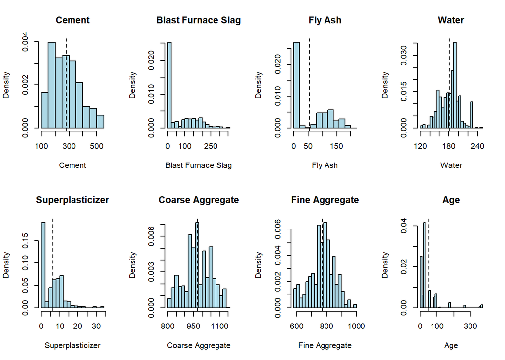

```r
par(mfrow = c(2, 4))

for (i in 1:p) {
 hist(dataset[,i],'FD',col = "lightblue",main = paste(colnames(dataset)[i]),xlab = colnames(dataset)[i],probability = TRUE)

  abline(v = mean(dataset[,i]) , lty = 2)
}
```

**From the histograms, one can observe that the data deviates due to the presence of a large number of zero values.**

### Boxplots

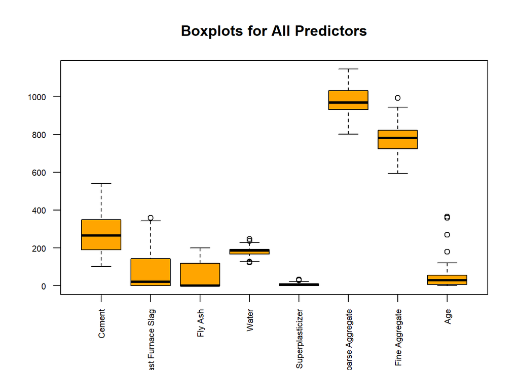

```r
 boxplot(dataset[,1:8], col = "orange", main = "Boxplots for All Predictors", cex.axis = 0.7,
        las = 2)
```

### Pair Plots

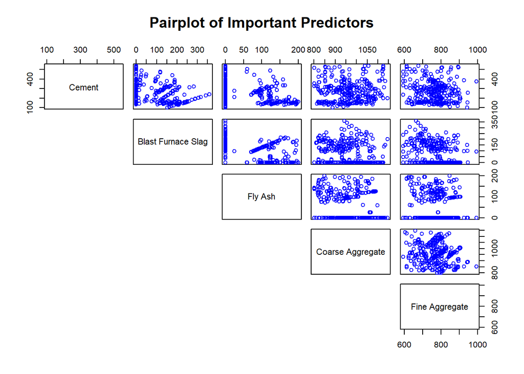

```r
pairs(dataset[,c(1,2,3,6,7)], main = "Pairplot of Important Predictors", col = "blue",lower.panel = NULL)
```

Concrete mixes often incorporate blast furnace slag, fly ash, or a combination of both. The three observed groups reflect this pattern:

Group 1: Mixes containing only fly ash (no slag).

Group 3: Mixes containing only blast furnace slag (no fly ash).

Group 2: Mixes that combine both materials (slag and fly ash).

### Questions

1. Is there a relationship between Predictors and Response(Concrete Compressive Strength)?
2. How Strong is the relationship between predictors and Response?
3. Is this relationship linear?
4. Will **Blast Furnace Slag, Fly Ash, Superplasticizer, and Age** be present in model selection?

### Correlations between predictors

#### Correlation matrix image

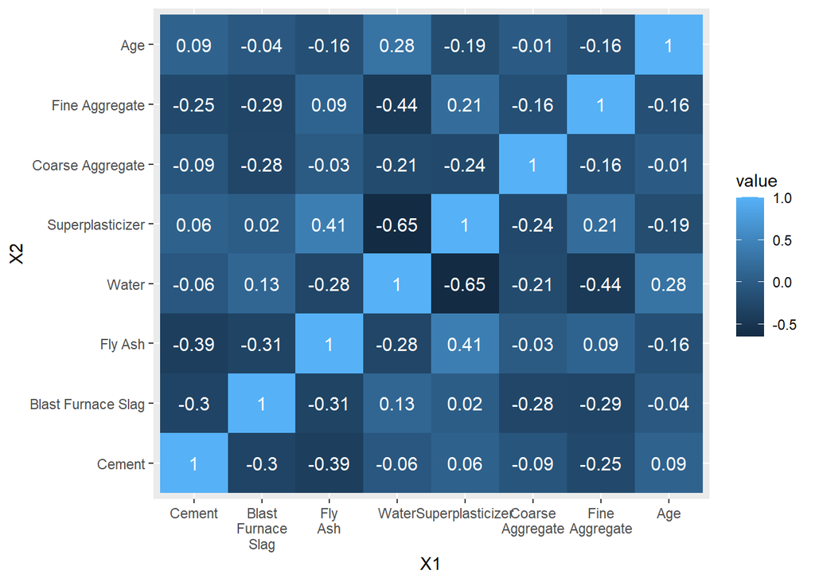

```r
#Load required libraries
library(ggplot2)
library(reshape)

#calculate correlation and transform it by melt() to make it suitable for ggplot
cormat = melt(cor(dataset[1:8]))


#plot the correlation and adjust width of x labels
ggplot(data = cormat,aes(x = X1,y = X2,fill = value))+
  geom_tile()  +                     #creates heatmap
  geom_text(aes(label = round(value, 2)), color = "white", size = 4)+                     #Add values inside tiles
scale_x_discrete(labels = function(x) stringr::str_wrap(x, width = 2))                        #Wrap long labels
```

#### Table of correlation and CI for each pair of variables

```r
cortable = NULL
#Iterate through all predictors
for(i in 1:p)
{
   for(j in (i+1):p)
   {
     #calculate correlation
    test = cor.test(dataset[,i],dataset[,j])
    #extract the necessary information and add to cortable
    cortable = rbind(cortable,c(colnames(dataset)[i],colnames(dataset)[j],signif(test$estimate,3),signif(test$conf.int,3),signif(test$p.value,3)))
   }

}

#name the columns
  colnames(cortable) <- c("Predictor1", "Predictor2", "Estimate", "Conf_Int_Lower", "Conf_Int_Upper", "p_value")

#exclude the last row
cortable = cortable[-nrow(cortable),]


#library to display in table format
library(DT)
datatable(cortable, caption = "Correlation Table with Confidence Intervals")
```

| Predictor1 | Predictor2 | Estimate | Conf_Int_Lower | Conf_Int_Upper | p_value |
| --- | --- | --- | --- | --- | --- |
| Cement | Blast Furnace Slag | -0.303 | -0.358 | -0.246 | 7.83e-23 |
| Cement | Fly Ash | -0.386 | -0.437 | -0.332 | 5.63e-37 |
| Cement | Water | -0.0566 | -0.118 | 0.00523 | 0.0728 |
| Cement | Superplasticizer | 0.0609 | -0.000936 | 0.122 | 0.0536 |
| Cement | Coarse Aggregate | -0.0862 | -0.147 | -0.0245 | 0.00625 |
| Cement | Fine Aggregate | -0.245 | -0.303 | -0.186 | 3.02e-15 |
| Cement | Age | 0.0863 | 0.0246 | 0.147 | 0.00616 |
| Blast Furnace Slag | Fly Ash | -0.312 | -0.367 | -0.255 | 3.5e-24 |
| Blast Furnace Slag | Water | 0.13 | 0.069 | 0.191 | 3.44e-05 |
| Blast Furnace Slag | Superplasticizer | 0.0198 | -0.0421 | 0.0815 | 0.531 |

[output cut: 19 more lines]

### Correlations between response and predictors

#### Table of correlation and CI between response and each predictor

```r
cor = NULL
#iterate through predictors
for(i in 1:p)
 {
  #calculate corelation
  test = cor.test(dataset[,i],dataset$CCS)
  #extract necesscary info and add to cor table
  cor = rbind(cor,c(colnames(dataset)[i],signif(test$estimate,3),signif(test$conf.int,3),signif(test$p.value,3)))
}

#name the columns
colnames(cor) = c("Predictor","Estimate", "Conf_Int_Lower", "Conf_Int_Upper", "p_value")

#display cor in table format
library(DT)
datatable(cor, caption = "Table of correlation and CI between response and each predictor ")
```

| Predictor | Estimate | Conf_Int_Lower | Conf_Int_Upper | p_value |
| --- | --- | --- | --- | --- |
| Cement | 0.488 | 0.44 | 0.534 | 2.46e-61 |
| Blast Furnace Slag | 0.103 | 0.0418 | 0.164 | 0.00103 |
| Fly Ash | -0.0806 | -0.142 | -0.0189 | 0.0105 |
| Water | -0.27 | -0.326 | -0.211 | 3.36e-18 |
| Superplasticizer | 0.344 | 0.289 | 0.398 | 2.48e-29 |
| Coarse Aggregate | -0.145 | -0.205 | -0.0836 | 4.1e-06 |
| Fine Aggregate | -0.186 | -0.245 | -0.126 | 2.59e-09 |
| Age | 0.337 | 0.281 | 0.391 | 3.57e-28 |

### Answers

1. There is , Significant relationship, as all predictors have low p-values and confidence intervals that do not include zero.
2. The strength of the relationship between predictors and concrete compressive strength varies.

# Linear Regression Analysis

## Simple Linear Regression Plots

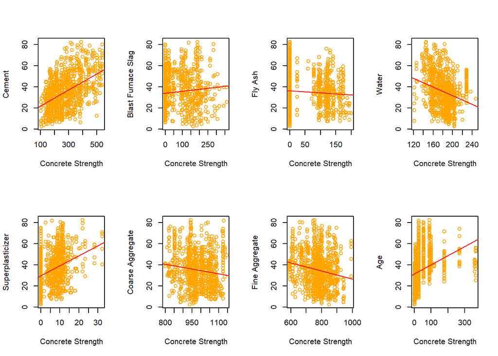

```r
par(mfrow = c(2,4))
# Initialize an empty list to store results
regression_summaries <- list()


for (i in 1:p) {
  predictor <- colnames(dataset)[i]  # Get predictor name

  # Fit linear regression
  model <- lm(CCS ~ dataset[[i]], data = dataset)

  plot(dataset[[i]],dataset$CCS,col = 'orange',xlab = "Concrete Strength",ylab = paste(predictor))

  abline(coef(model),col = 'red')


  # Extract summary statistics
  summary_fit <- summary(model)

  # Store results in a structured table (data frame)
  regression_table <- data.frame(
    Coefficient = summary_fit$coefficients[, 1],
    Std_Error = summary_fit$coefficients[, 2],
    t_Statistic = summary_fit$coefficients[, 3],
    p_Value = summary_fit$coefficients[, 4]
  )

  # Store the table in the list
  regression_summaries[[predictor]] <- regression_table
}
```

## Regression Summaries

```r
print(regression_summaries)
```

```
## $Cement
##              Coefficient   Std_Error t_Statistic      p_Value
## (Intercept)  14.01714380 1.279449789    10.95560 1.841946e-26
## dataset[[i]]  0.07620548 0.004300524    17.72004 2.462066e-61
##
## $`Blast Furnace Slag`
##              Coefficient   Std_Error t_Statistic       p_Value
## (Intercept)  33.84294102 0.666449457   50.780957 1.772964e-279
## dataset[[i]]  0.01953594 0.005935253    3.291509  1.031267e-03
##
## $`Fly Ash`
##              Coefficient   Std_Error t_Statistic       p_Value
## (Intercept)  36.38634425 0.677451913   53.710593 2.399769e-297
## dataset[[i]] -0.02045447 0.007982271   -2.562488  1.053756e-02
##
## $Water
##              Coefficient  Std_Error t_Statistic      p_Value
## (Intercept)   72.7141610 4.25375928   17.094094 1.089370e-57
## dataset[[i]]  -0.2057598 0.02320397   -8.867439 3.362909e-18
##
## $Superplasticizer
##              Coefficient  Std_Error t_Statistic      p_Value
## (Intercept)   29.5377520 0.68914712    42.86132 6.33484e-229
## dataset[[i]]   0.9468597 0.08155099    11.61065  2.48425e-29
##
## $`Coarse Aggregate`
##              Coefficient   Std_Error t_Statistic      p_Value
## (Intercept)  64.84977888 6.410416042   10.116314 5.662918e-23
## dataset[[i]] -0.03037778 0.006558257   -4.631989 4.097881e-06
##
## $`Fine Aggregate`
##              Coefficient   Std_Error t_Statistic      p_Value
## (Intercept)   64.4522737 4.884860268   13.194292 9.020573e-37
## dataset[[i]]  -0.0377926 0.006288039   -6.010236 2.590052e-09
##
## $Age
##              Coefficient   Std_Error t_Statistic       p_Value
## (Intercept)  31.29750917 0.596129576    52.50119 5.016096e-290
## dataset[[i]]  0.08620044 0.007594835    11.34988  3.571949e-28
```

### **Regression Insights for Each Predictor:**

#### Cement (Positive Linear Relationship)

> The scatter plot shows a clear positive trend.

> Cement appears to be a strong predictor for concrete strength.

> A linear regression model yields a statistically significant positive coefficient.

#### Blast Furnace Slag (Weak Positive)

> The trend is slightly positive but weak.

#### Fly Ash (Weak or Negative Relationship)

> The red line (regression line) is almost flat or slightly declining.

> Likely a small or negative coefficient in a regression model.

> Might not be a strong predictor.

#### Water (Negative Relationship)

> A clear negative linear trend.

> Regression summaries shows a statistically significant negative coefficient.

#### Superplasticizer (Positive Relationship)

#### Coarse Aggregate (Weak Negative Relationship)

> The regression line slopes downward slightly.

> A small negative coefficient, meaning increasing coarse aggregate alone does not improve strength.

#### Fine Aggregate (Weak Negative Relationship)

> Similar to coarse aggregate, weak negative trend.

#### Age (Strong Positive Relationship)

> In regression, age would has a positive coefficient and is a significant predictor.

## Residual Plots

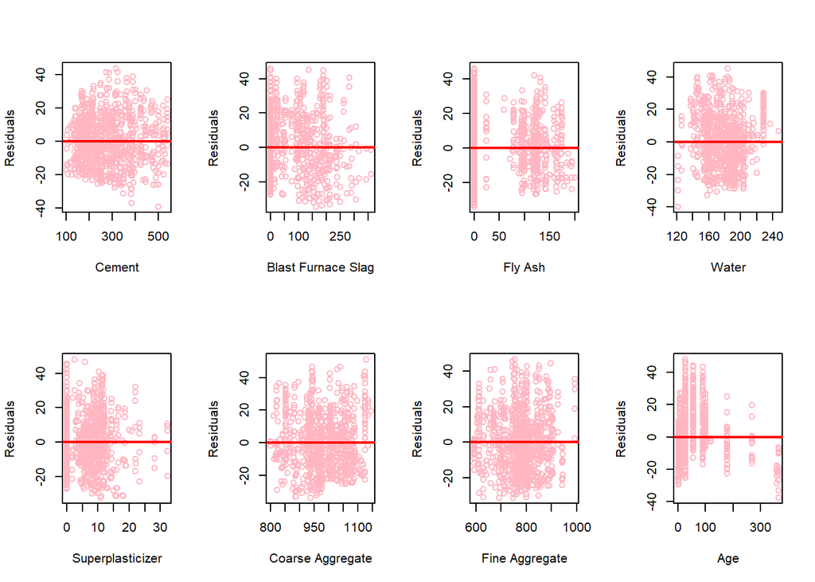

```r
par(mfrow = c(2, 4))
for (i in 1:p) {
  # Fit linear regression
  model <- lm(CCS ~ dataset[[i]], data = dataset)

  # Extract residual
  residuals  <- resid(model)

  #Plot residuals as function of x
  plot(dataset[[i]],residuals, xlab = paste(colnames(dataset)[i]), ylab = "Residuals", col = "lightpink")

  abline(h = 0, col = "red", lwd = 2)  # Add a horizontal line at zero
}
```

## Multiple Linear Regression

```r
# Fit multiple linear regression model
model = lm(CCS ~ ., data = dataset)

# Print model summary
summary(model)
```

```
##
## Call:
## lm(formula = CCS ~ ., data = dataset)
##
## Residuals:
##     Min      1Q  Median      3Q     Max
## -28.140  -6.304   0.599   6.647  34.994
##
## Coefficients:
##                        Estimate Std. Error t value Pr(>|t|)
## (Intercept)          -17.919839  26.416324  -0.678 0.497700
## Cement                 0.117242   0.008495  13.802  < 2e-16 ***
## `Blast Furnace Slag`   0.099466   0.010157   9.793  < 2e-16 ***
## `Fly Ash`              0.085624   0.012476   6.863 1.19e-11 ***
## Water                 -0.152247   0.039798  -3.825 0.000139 ***
## Superplasticizer       0.284935   0.092893   3.067 0.002218 **
## `Coarse Aggregate`     0.015678   0.009319   1.682 0.092832 .
## `Fine Aggregate`       0.018329   0.010674   1.717 0.086246 .
## Age                    0.112178   0.005393  20.801  < 2e-16 ***
## ---
## Signif. codes:  0 '***' 0.001 '**' 0.01 '*' 0.05 '.' 0.1 ' ' 1
##
## Residual standard error: 10.29 on 996 degrees of freedom
## Multiple R-squared:  0.6039, Adjusted R-squared:  0.6007
## F-statistic: 189.8 on 8 and 996 DF,  p-value: < 2.2e-16
```

# Model Selection

## Forward Stepwise Selection

```r
#start with empty predictors
first_start = lm(CCS ~ 1,data = dataset)
```

### Model Selection Based on AIC Score

```r
# Stepwise selection using AIC
stepwise_AIC = step(first_start,direction = "forward",scope = formula(model))
```

```
Step:  AIC = 4832.91
CCS ~ Cement + Superplasticizer + Age + `Blast Furnace Slag` +      Water + `Fly Ash`
```

### Answer

4. The predictors with high deviation show up in Model Selection.

## Conclusion

The dataset does **not exhibit a strictly linear relationship** between all predictors and **CCS**. While some variables have clear linear trends.